# Spotify Dataset 1922-2021, ~600k Tracks

## by Abdulrahman Yaseen

## Investigation Overview

I wanted to look in figuring out what features are best for predicting the popularity of the tracks in the dataset

## Dataset Overview

There are 586672 tracks in the dataset with 19 features

### Features:

- acousticness (Ranges from 0 to 1)
- danceability (Ranges from 0 to 1)
- energy (Ranges from 0 to 1)
- duration_ms (Integer typically ranging from 200k to 300k)
- instrumentalness (Ranges from 0 to 1)
- valence (Ranges from 0 to 1)
- popularity (Ranges from 0 to 100)
- tempo (Float typically ranging from 50 to 150)
- liveness (Ranges from 0 to 1)
- loudness (Float typically ranging from -60 to 0)
- speechiness (Ranges from 0 to 1)
- mode (0 = Minor, 1 = Major)
- explicit (0 = No explicit content, 1 = Explicit content)
- key (All keys on octave encoded as values ranging from 0 to 11, starting on C as 0, C# as 1 and so on…)
- timesignature (The predicted timesignature, most typically 4)
- artists (List of artists mentioned)
- release_date (Date of release mostly in yyyy-mm-dd format, however precision of date may vary)
- name (Name of the song)

## Popularity Distribution

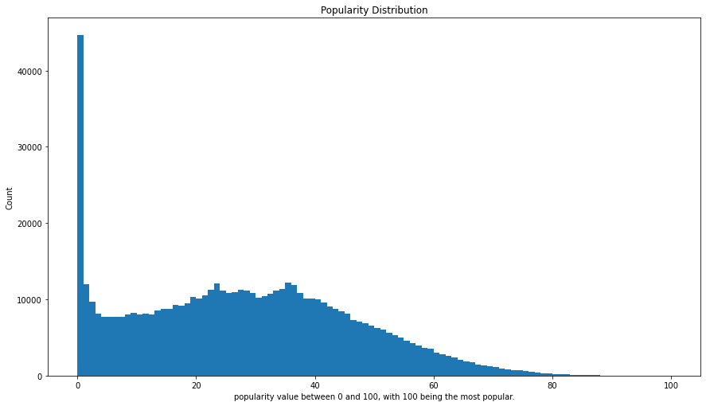

## Duration Distribution

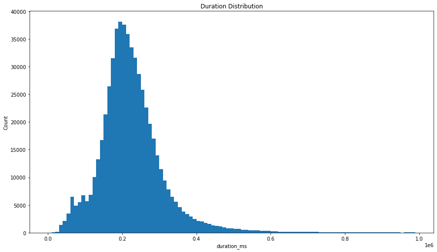

## (Track Releases Over Years)

> The production of songs is increasing over years

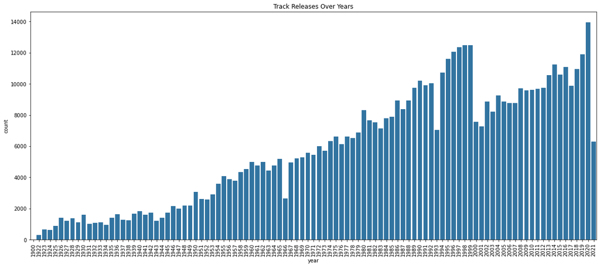

## The First Feature Affecting The Popularity

> The more energtic the more popular

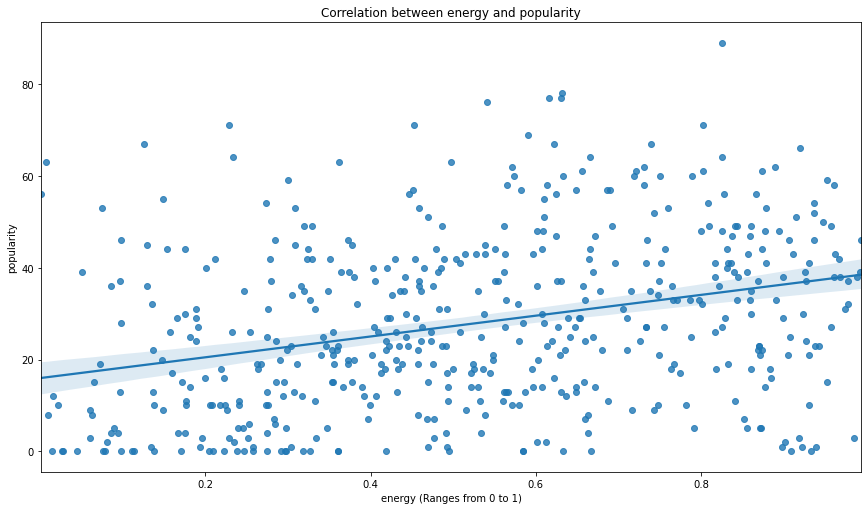

## The Seacond Feature Affecting The Popularity

> The more loud the more popular

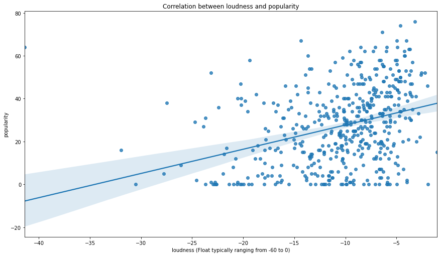

## Audio Characteristics Over Years

> Tracks have become more Energetic and Danceable in the recent years. The loudness and tempo has also increased. The tracks have become less "Acoustic" Also the more energetic and loud the more popular

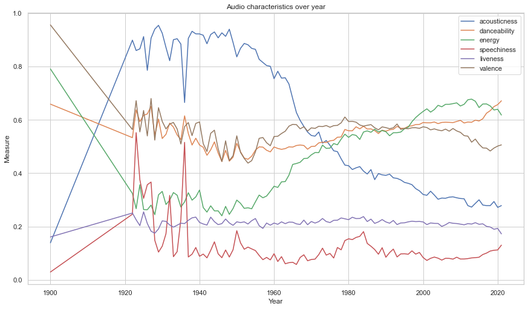

### Further looking into energy effect taking loudness range and years in consideration

> "popularity VS "energy" by "years" and with size "loudness_range"

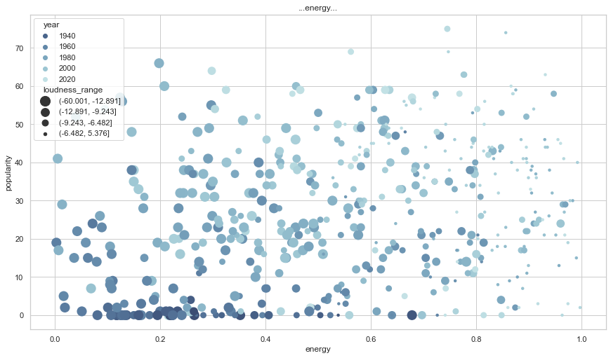

### Further looking into danceability effect taking loudness range and years in consideration

> "popularity VS "danceability" by "years" and with size "loudness_range"

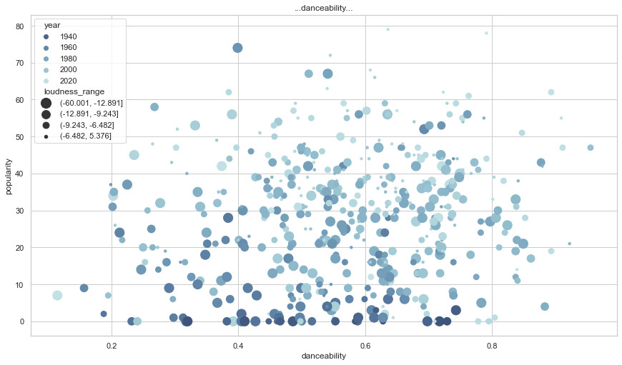